# Consumer Price Index

Dataset location : [fred Economic research](https://fred.stlouisfed.org/series/CPIAUCSL)

**Dataset info**

The Consumer Price Index for All Urban Consumers: All Items (CPIAUCSL) is a measure of the average monthly change in the price for goods and services paid by urban consumers between any two time periods.(1) It can also represent the buying habits of urban consumers. This particular index includes roughly 88 percent of the total population, accounting for wage earners, clerical workers, technical workers, self-employed, short-term workers, unemployed, retirees, and those not in the labor force.

**Note** This information copied from Fred website . For all details please check Notes section on https://fred.stlouisfed.org/series/CPIAUCSL

**Business Problem**

This is time series forecasting problem and there are lot of techniques to solve this problem, for example

1. Using facebook prophet library
2. using statsmodels time series
3. Using Deep learning like LSTM with keras

Here we will use 1st approach to solve the time series forecasting problem

1. First we have to download the fbprophet library
2. Import fbprophet library
3. Also import other analysis and visualization library like pandas, matplotlib

```python
# Analysis library
import pandas as pd

#visualization library
import matplotlib.pyplot as plt

#facebook time series analysis library
from fbprophet import Prophet

#python library to avoid warnings log events
import warnings

#statsmodel library
from statsmodels.tools.eval_measures import rmse

from fbprophet.plot import add_changepoints_to_plot
```

```python
warnings.filterwarnings('ignore')
```

### Load the dataset into notebook

1. Using pandas , load the consumer price index dataset into notebook
2. if you look into the first few columns of the dataset, there are 2 columns only, date & CPIAUCSL
3. First of all, while using prophet library for , prophet is only understand columns with the name of 'ds', 'y'
4. then we need to check date format of the dataset , if date format is in require pandas format then we are good to go, otherwise we need to convert date columns with pandas datetime index using to_datetime().
5. lets look into the info() of the dataset, anow dataset is good to abalysis and there is no missing value in dataset.
6. from data , its look like data is present in frequency of month

```python
data=pd.read_csv('CPIAUCSL.csv')
data.head()
```

|  | DATE | CPIAUCSL |
| --- | --- | --- |
| 0 | 1947-01-01 | 21.48 |
| 1 | 1947-02-01 | 21.62 |
| 2 | 1947-03-01 | 22.00 |
| 3 | 1947-04-01 | 22.00 |
| 4 | 1947-05-01 | 21.95 |

```python
data.columns=['ds','y']
data['ds']=pd.to_datetime(data['ds'])
data.tail()
```

|  | ds | y |
| --- | --- | --- |
| 863 | 2018-12-01 | 252.723 |
| 864 | 2019-01-01 | 252.673 |
| 865 | 2019-02-01 | 253.113 |
| 866 | 2019-03-01 | 254.148 |
| 867 | 2019-04-01 | 254.958 |

```python
data.info()
```

```
<class 'pandas.core.frame.DataFrame'>
RangeIndex: 868 entries, 0 to 867
Data columns (total 2 columns):
ds    868 non-null datetime64[ns]
y     868 non-null float64
dtypes: datetime64[ns](1), float64(1)
memory usage: 13.6 KB
```

### visualization

1. with matplotlib ,lets plot the line graph for given data.
2. its look like, data is trending upward with timelapse.
3. from this line plot, we can not sure that there is seasonality present in dataset or not, which we will look into later

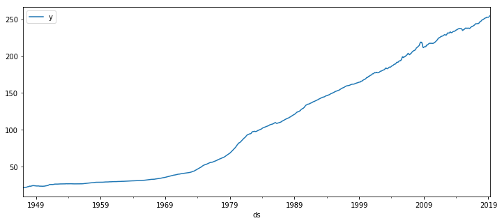

```python
data.plot(x='ds',y='y',figsize=(12,5))
```

### dataset splitting for train & test

1. To create a model and to train it , we have to split our dataset into 2 parts, train & test
2. out of 868 months extry , we will take first 820 entry for training the model and 48 months for tresting the model.

```python
train=data.iloc[:820]
test=data.iloc[820:]
```

```python
test.info()
```

```
<class 'pandas.core.frame.DataFrame'>
RangeIndex: 48 entries, 820 to 867
Data columns (total 2 columns):
ds    48 non-null datetime64[ns]
y     48 non-null float64
dtypes: datetime64[ns](1), float64(1)
memory usage: 852.0 bytes
```

### Model creation using prophet

1. As earlier mentioned, we are using fbprophet library for forecasting time series
2. using Phophet(), lets initalize the model
3. then train the model using fit()
4. In prophet we need to use make_future_dataframe() wehere we need to give input for which we need to make forecasting and frequency of the datset
5. here we are providing periods=48 and freq='MS'
6. after predicting the future price, lets look into its results.
7. from forecast , we require only 2 columns 'ds' & 'yhat'

```python
fbpro=Prophet()
fbpro.fit(train)
future=fbpro.make_future_dataframe(48,freq='MS')
forecast=fbpro.predict(future)
```

```
INFO:fbprophet:Disabling weekly seasonality. Run prophet with weekly_seasonality=True to override this.
INFO:fbprophet:Disabling daily seasonality. Run prophet with daily_seasonality=True to override this.
```

```python
forecast
```

|  | ds | trend | yhat_lower | yhat_upper | trend_lower | trend_upper | additive_terms | additive_terms_lower | additive_terms_upper | yearly | yearly_lower | yearly_upper | multiplicative_terms | multiplicative_terms_lower | multiplicative_terms_upper | yhat |
| --- | --- | --- | --- | --- | --- | --- | --- | --- | --- | --- | --- | --- | --- | --- | --- | --- |
| 0 | 1947-01-01 | 22.387884 | 20.866473 | 23.883076 | 22.387884 | 22.387884 | -0.120755 | -0.120755 | -0.120755 | -0.120755 | -0.120755 | -0.120755 | 0.0 | 0.0 | 0.0 | 22.267129 |
| 1 | 1947-02-01 | 22.449490 | 20.847954 | 23.850634 | 22.449490 | 22.449490 | -0.081634 | -0.081634 | -0.081634 | -0.081634 | -0.081634 | -0.081634 | 0.0 | 0.0 | 0.0 | 22.367856 |
| 2 | 1947-03-01 | 22.505135 | 20.604671 | 23.720720 | 22.505135 | 22.505135 | -0.307074 | -0.307074 | -0.307074 | -0.307074 | -0.307074 | -0.307074 | 0.0 | 0.0 | 0.0 | 22.198060 |
| 3 | 1947-04-01 | 22.566741 | 20.823589 | 23.735006 | 22.566741 | 22.566741 | -0.235705 | -0.235705 | -0.235705 | -0.235705 | -0.235705 | -0.235705 | 0.0 | 0.0 | 0.0 | 22.331036 |
| 4 | 1947-05-01 | 22.626359 | 21.279276 | 24.180817 | 22.626359 | 22.626359 | 0.045742 | 0.045742 | 0.045742 | 0.045742 | 0.045742 | 0.045742 | 0.0 | 0.0 | 0.0 | 22.672101 |
| 5 | 1947-06-01 | 22.687965 | 21.300066 | 24.345364 | 22.687965 | 22.687965 | 0.036263 | 0.036263 | 0.036263 | 0.036263 | 0.036263 | 0.036263 | 0.0 | 0.0 | 0.0 | 22.724229 |
| 6 | 1947-07-01 | 22.747584 | 21.364350 | 24.400634 | 22.747584 | 22.747584 | 0.063548 | 0.063548 | 0.063548 | 0.063548 | 0.063548 | 0.063548 | 0.0 | 0.0 | 0.0 | 22.811132 |
| 7 | 1947-08-01 | 22.809190 | 21.335211 | 24.390428 | 22.809190 | 22.809190 | 0.049322 | 0.049322 | 0.049322 | 0.049322 | 0.049322 | 0.049322 | 0.0 | 0.0 | 0.0 | 22.858512 |
| 8 | 1947-09-01 | 22.870796 | 21.427174 | 24.538132 | 22.870796 | 22.870796 | 0.019640 | 0.019640 | 0.019640 | 0.019640 | 0.019640 | 0.019640 | 0.0 | 0.0 | 0.0 | 22.890436 |
| 9 | 1947-10-01 | 22.930415 | 21.371056 | 24.352792 | 22.930415 | 22.930415 | -0.095389 | -0.095389 | -0.095389 | -0.095389 | -0.095389 | -0.095389 | 0.0 | 0.0 | 0.0 | 22.835026 |
| 10 | 1947-11-01 | 22.992021 | 21.383949 | 24.422912 | 22.992021 | 22.992021 | -0.107950 | -0.107950 | -0.107950 | -0.107950 | -0.107950 | -0.107950 | 0.0 | 0.0 | 0.0 | 22.884071 |
| 11 | 1947-12-01 | 23.051640 | 21.419783 | 24.485974 | 23.051640 | 23.051640 | -0.113632 | -0.113632 | -0.113632 | -0.113632 | -0.113632 | -0.113632 | 0.0 | 0.0 | 0.0 | 22.938008 |
| 12 | 1948-01-01 | 23.113246 | 21.490028 | 24.584056 | 23.113246 | 23.113246 | -0.066617 | -0.066617 | -0.066617 | -0.066617 | -0.066617 | -0.066617 | 0.0 | 0.0 | 0.0 | 23.046629 |
| 13 | 1948-02-01 | 23.174852 | 21.697360 | 24.586340 | 23.174852 | 23.174852 | 0.002211 | 0.002211 | 0.002211 | 0.002211 | 0.002211 | 0.002211 | 0.0 | 0.0 | 0.0 | 23.177062 |
| 14 | 1948-03-01 | 23.232483 | 21.734246 | 24.809005 | 23.232483 | 23.232483 | 0.069418 | 0.069418 | 0.069418 | 0.069418 | 0.069418 | 0.069418 | 0.0 | 0.0 | 0.0 | 23.301902 |
| 15 | 1948-04-01 | 23.294089 | 21.713466 | 24.595118 | 23.294089 | 23.294089 | -0.021387 | -0.021387 | -0.021387 | -0.021387 | -0.021387 | -0.021387 | 0.0 | 0.0 | 0.0 | 23.272702 |
| 16 | 1948-05-01 | 23.353708 | 21.696403 | 24.755533 | 23.353708 | 23.353708 | -0.153457 | -0.153457 | -0.153457 | -0.153457 | -0.153457 | -0.153457 | 0.0 | 0.0 | 0.0 | 23.200251 |
| 17 | 1948-06-01 | 23.415314 | 21.886693 | 24.912259 | 23.415314 | 23.415314 | -0.051439 | -0.051439 | -0.051439 | -0.051439 | -0.051439 | -0.051439 | 0.0 | 0.0 | 0.0 | 23.363875 |
| 18 | 1948-07-01 | 23.474933 | 21.794012 | 24.875087 | 23.474933 | 23.474933 | -0.033315 | -0.033315 | -0.033315 | -0.033315 | -0.033315 | -0.033315 | 0.0 | 0.0 | 0.0 | 23.441618 |
| 19 | 1948-08-01 | 23.536539 | 22.025680 | 25.049364 | 23.536539 | 23.536539 | -0.001536 | -0.001536 | -0.001536 | -0.001536 | -0.001536 | -0.001536 | 0.0 | 0.0 | 0.0 | 23.535003 |
| 20 | 1948-09-01 | 23.598145 | 22.227236 | 25.201765 | 23.598145 | 23.598145 | 0.108292 | 0.108292 | 0.108292 | 0.108292 | 0.108292 | 0.108292 | 0.0 | 0.0 | 0.0 | 23.706437 |
| 21 | 1948-10-01 | 23.657763 | 22.155563 | 25.250319 | 23.657763 | 23.657763 | 0.122444 | 0.122444 | 0.122444 | 0.122444 | 0.122444 | 0.122444 | 0.0 | 0.0 | 0.0 | 23.780207 |
| 22 | 1948-11-01 | 23.719369 | 22.029580 | 25.195314 | 23.719369 | 23.719369 | -0.080790 | -0.080790 | -0.080790 | -0.080790 | -0.080790 | -0.080790 | 0.0 | 0.0 | 0.0 | 23.638580 |
| 23 | 1948-12-01 | 23.778988 | 22.135374 | 25.205068 | 23.778988 | 23.778988 | -0.219202 | -0.219202 | -0.219202 | -0.219202 | -0.219202 | -0.219202 | 0.0 | 0.0 | 0.0 | 23.559786 |
| 24 | 1949-01-01 | 23.840594 | 21.990205 | 25.125177 | 23.840594 | 23.840594 | -0.228287 | -0.228287 | -0.228287 | -0.228287 | -0.228287 | -0.228287 | 0.0 | 0.0 | 0.0 | 23.612307 |
| 25 | 1949-02-01 | 23.902200 | 22.066605 | 25.122253 | 23.902200 | 23.902200 | -0.257345 | -0.257345 | -0.257345 | -0.257345 | -0.257345 | -0.257345 | 0.0 | 0.0 | 0.0 | 23.644855 |
| 26 | 1949-03-01 | 23.957844 | 22.494787 | 25.462709 | 23.957844 | 23.957844 | -0.054341 | -0.054341 | -0.054341 | -0.054341 | -0.054341 | -0.054341 | 0.0 | 0.0 | 0.0 | 23.903504 |
| 27 | 1949-04-01 | 24.019450 | 22.316354 | 25.463250 | 24.019450 | 24.019450 | -0.095358 | -0.095358 | -0.095358 | -0.095358 | -0.095358 | -0.095358 | 0.0 | 0.0 | 0.0 | 23.924092 |
| 28 | 1949-05-01 | 24.079069 | 22.429883 | 25.484712 | 24.079069 | 24.079069 | -0.089219 | -0.089219 | -0.089219 | -0.089219 | -0.089219 | -0.089219 | 0.0 | 0.0 | 0.0 | 23.989850 |
| 29 | 1949-06-01 | 24.140675 | 22.598802 | 25.541809 | 24.140675 | 24.140675 | -0.022360 | -0.022360 | -0.022360 | -0.022360 | -0.022360 | -0.022360 | 0.0 | 0.0 | 0.0 | 24.118315 |
| ... | ... | ... | ... | ... | ... | ... | ... | ... | ... | ... | ... | ... | ... | ... | ... | ... |
| 838 | 2016-11-01 | 249.549335 | 247.881649 | 251.361980 | 249.166407 | 250.051069 | -0.080790 | -0.080790 | -0.080790 | -0.080790 | -0.080790 | -0.080790 | 0.0 | 0.0 | 0.0 | 249.468545 |
| 839 | 2016-12-01 | 249.938417 | 248.067425 | 251.407592 | 249.469926 | 250.526052 | -0.219202 | -0.219202 | -0.219202 | -0.219202 | -0.219202 | -0.219202 | 0.0 | 0.0 | 0.0 | 249.719215 |
| 840 | 2017-01-01 | 250.340470 | 248.373420 | 251.875988 | 249.805342 | 251.012450 | -0.228287 | -0.228287 | -0.228287 | -0.228287 | -0.228287 | -0.228287 | 0.0 | 0.0 | 0.0 | 250.112182 |
| 841 | 2017-02-01 | 250.742522 | 248.869928 | 252.456426 | 250.126512 | 251.500223 | -0.257345 | -0.257345 | -0.257345 | -0.257345 | -0.257345 | -0.257345 | 0.0 | 0.0 | 0.0 | 250.485176 |
| 842 | 2017-03-01 | 251.105666 | 249.386545 | 252.961494 | 250.430055 | 251.931608 | -0.054341 | -0.054341 | -0.054341 | -0.054341 | -0.054341 | -0.054341 | 0.0 | 0.0 | 0.0 | 251.051325 |
| 843 | 2017-04-01 | 251.507718 | 249.539724 | 253.276231 | 250.763252 | 252.383416 | -0.095358 | -0.095358 | -0.095358 | -0.095358 | -0.095358 | -0.095358 | 0.0 | 0.0 | 0.0 | 251.412360 |
| 844 | 2017-05-01 | 251.896801 | 249.943870 | 253.855511 | 251.088718 | 252.825889 | -0.089219 | -0.089219 | -0.089219 | -0.089219 | -0.089219 | -0.089219 | 0.0 | 0.0 | 0.0 | 251.807582 |
| 845 | 2017-06-01 | 252.298853 | 250.436898 | 254.367525 | 251.401857 | 253.285357 | -0.022360 | -0.022360 | -0.022360 | -0.022360 | -0.022360 | -0.022360 | 0.0 | 0.0 | 0.0 | 252.276493 |
| 846 | 2017-07-01 | 252.687936 | 250.660618 | 254.809514 | 251.715895 | 253.752272 | -0.000290 | -0.000290 | -0.000290 | -0.000290 | -0.000290 | -0.000290 | 0.0 | 0.0 | 0.0 | 252.687646 |
| 847 | 2017-08-01 | 253.089988 | 251.162344 | 255.097868 | 252.022519 | 254.216157 | 0.017067 | 0.017067 | 0.017067 | 0.017067 | 0.017067 | 0.017067 | 0.0 | 0.0 | 0.0 | 253.107055 |
| 848 | 2017-09-01 | 253.492040 | 251.508110 | 255.953713 | 252.320225 | 254.736932 | 0.080406 | 0.080406 | 0.080406 | 0.080406 | 0.080406 | 0.080406 | 0.0 | 0.0 | 0.0 | 253.572447 |
| 849 | 2017-10-01 | 253.881123 | 251.808822 | 256.211145 | 252.639552 | 255.228642 | 0.049296 | 0.049296 | 0.049296 | 0.049296 | 0.049296 | 0.049296 | 0.0 | 0.0 | 0.0 | 253.930419 |
| 850 | 2017-11-01 | 254.283175 | 252.124401 | 256.384426 | 252.954708 | 255.699787 | -0.091950 | -0.091950 | -0.091950 | -0.091950 | -0.091950 | -0.091950 | 0.0 | 0.0 | 0.0 | 254.191225 |
| 851 | 2017-12-01 | 254.672258 | 252.330827 | 256.795792 | 253.268150 | 256.178216 | -0.185565 | -0.185565 | -0.185565 | -0.185565 | -0.185565 | -0.185565 | 0.0 | 0.0 | 0.0 | 254.486693 |
| 852 | 2018-01-01 | 255.074310 | 252.717361 | 257.119758 | 253.573116 | 256.660371 | -0.174679 | -0.174679 | -0.174679 | -0.174679 | -0.174679 | -0.174679 | 0.0 | 0.0 | 0.0 | 254.899631 |
| 853 | 2018-02-01 | 255.476362 | 252.909442 | 257.815499 | 253.820443 | 257.118792 | -0.168186 | -0.168186 | -0.168186 | -0.168186 | -0.168186 | -0.168186 | 0.0 | 0.0 | 0.0 | 255.308177 |
| 854 | 2018-03-01 | 255.839506 | 253.290559 | 258.080487 | 254.054868 | 257.597354 | -0.179892 | -0.179892 | -0.179892 | -0.179892 | -0.179892 | -0.179892 | 0.0 | 0.0 | 0.0 | 255.659615 |
| 855 | 2018-04-01 | 256.241558 | 253.791091 | 258.577940 | 254.343264 | 258.100305 | -0.166833 | -0.166833 | -0.166833 | -0.166833 | -0.166833 | -0.166833 | 0.0 | 0.0 | 0.0 | 256.074725 |
| 856 | 2018-05-01 | 256.630641 | 254.065785 | 259.134832 | 254.613476 | 258.647935 | -0.022796 | -0.022796 | -0.022796 | -0.022796 | -0.022796 | -0.022796 | 0.0 | 0.0 | 0.0 | 256.607845 |
| 857 | 2018-06-01 | 257.032693 | 254.460740 | 259.796064 | 254.883855 | 259.124480 | 0.006897 | 0.006897 | 0.006897 | 0.006897 | 0.006897 | 0.006897 | 0.0 | 0.0 | 0.0 | 257.039590 |
| 858 | 2018-07-01 | 257.421776 | 254.909271 | 260.208114 | 255.192536 | 259.646740 | 0.032017 | 0.032017 | 0.032017 | 0.032017 | 0.032017 | 0.032017 | 0.0 | 0.0 | 0.0 | 257.453793 |
| 859 | 2018-08-01 | 257.823828 | 255.224153 | 260.795558 | 255.437551 | 260.144443 | 0.034027 | 0.034027 | 0.034027 | 0.034027 | 0.034027 | 0.034027 | 0.0 | 0.0 | 0.0 | 257.857855 |
| 860 | 2018-09-01 | 258.225881 | 255.407141 | 261.093396 | 255.775602 | 260.694208 | 0.050838 | 0.050838 | 0.050838 | 0.050838 | 0.050838 | 0.050838 | 0.0 | 0.0 | 0.0 | 258.276718 |
| 861 | 2018-10-01 | 258.614963 | 255.846906 | 261.691744 | 256.080030 | 261.229373 | -0.023349 | -0.023349 | -0.023349 | -0.023349 | -0.023349 | -0.023349 | 0.0 | 0.0 | 0.0 | 258.591614 |
| 862 | 2018-11-01 | 259.017016 | 256.092891 | 262.176530 | 256.402589 | 261.755657 | -0.101012 | -0.101012 | -0.101012 | -0.101012 | -0.101012 | -0.101012 | 0.0 | 0.0 | 0.0 | 258.916004 |
| 863 | 2018-12-01 | 259.406098 | 256.198878 | 262.432526 | 256.719034 | 262.253169 | -0.150354 | -0.150354 | -0.150354 | -0.150354 | -0.150354 | -0.150354 | 0.0 | 0.0 | 0.0 | 259.255744 |
| 864 | 2019-01-01 | 259.808151 | 256.639087 | 262.859481 | 257.011895 | 262.805133 | -0.120755 | -0.120755 | -0.120755 | -0.120755 | -0.120755 | -0.120755 | 0.0 | 0.0 | 0.0 | 259.687396 |
| 865 | 2019-02-01 | 260.210203 | 256.848169 | 263.528219 | 257.274037 | 263.267574 | -0.081634 | -0.081634 | -0.081634 | -0.081634 | -0.081634 | -0.081634 | 0.0 | 0.0 | 0.0 | 260.128568 |
| 866 | 2019-03-01 | 260.573347 | 256.832711 | 263.814890 | 257.581068 | 263.723288 | -0.307074 | -0.307074 | -0.307074 | -0.307074 | -0.307074 | -0.307074 | 0.0 | 0.0 | 0.0 | 260.266273 |
| 867 | 2019-04-01 | 260.975399 | 257.423136 | 264.329254 | 257.887107 | 264.276395 | -0.235705 | -0.235705 | -0.235705 | -0.235705 | -0.235705 | -0.235705 | 0.0 | 0.0 | 0.0 | 260.739694 |

868 rows × 16 columns

### Prediction evaluation with plotting results

1. now, lets plot the test data & forecasted data
2. with the below plot it's look like our forecast model has predicted good values as both the line are very close to each other
3. but there are some error in between prediction and acual , let's find out that error value

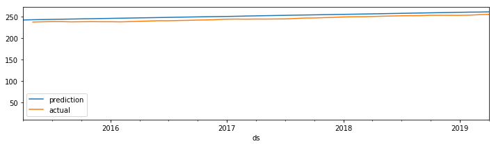

```python
ax=forecast.plot(x='ds',y='yhat',figsize=(12,3),label='prediction',legend=True)
test.plot(x='ds',y='y',label='actual',legend=True,ax=ax,xlim=('2015-04-01','2019-04-01'))
```

### Root mean square error for model

1. we use statsmodels rmse error to find out error from both the results
2. its look like there is very less rmse between both the results , means our model has predicted accurate results

```python
testpred=forecast.iloc[-48:]['yhat']
rmse(testpred,test['y'])
```

```
6.876652011932644
```

### forecasting visualization

1. Plot showed actual data with forecasted values with its lower & upper bond
2. from complonents we can find out trend of dataset & seasonality of data
3. its look like there is some seasonality is present in dataset
4. before finalizing model , we need to check models rmse with adding seasonality factor

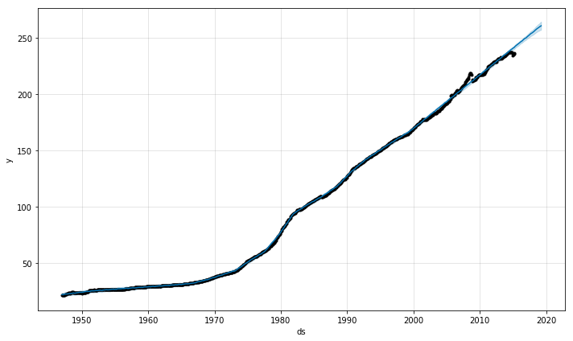

```python
fig=fbpro.plot(forecast)
```

[figure not shown]

```python
fig=fbpro.plot_components(forecast)
```

### Model with adding seasonality

```python
fbpro1=Prophet(seasonality_mode='multiplicative')
fbpro1.fit(train)
future=fbpro1.make_future_dataframe(48,freq='MS')
forecast1=fbpro1.predict(future)
```

```
INFO:fbprophet:Disabling weekly seasonality. Run prophet with weekly_seasonality=True to override this.
INFO:fbprophet:Disabling daily seasonality. Run prophet with daily_seasonality=True to override this.
```

```python
testpred=forecast1.iloc[-48:]['yhat']
rmse(testpred,test['y'])
```

```
6.916705290134479
```

[figure not shown]

```python
fig=fbpro.plot_components(forecast1)
```

### Use the model & Predict the future value for next 24 months

```python
fbpro=Prophet()
fbpro.fit(data)
future=fbpro.make_future_dataframe(24,freq='MS')
forecast_future=fbpro.predict(future)
```

```
INFO:fbprophet:Disabling weekly seasonality. Run prophet with weekly_seasonality=True to override this.
INFO:fbprophet:Disabling daily seasonality. Run prophet with daily_seasonality=True to override this.
```

### forecasting values of next 24 months

```python
forecast_future
```

|  | ds | trend | yhat_lower | yhat_upper | trend_lower | trend_upper | additive_terms | additive_terms_lower | additive_terms_upper | yearly | yearly_lower | yearly_upper | multiplicative_terms | multiplicative_terms_lower | multiplicative_terms_upper | yhat |
| --- | --- | --- | --- | --- | --- | --- | --- | --- | --- | --- | --- | --- | --- | --- | --- | --- |
| 0 | 1947-01-01 | 22.339322 | 20.520927 | 23.911022 | 22.339322 | 22.339322 | -0.062102 | -0.062102 | -0.062102 | -0.062102 | -0.062102 | -0.062102 | 0.0 | 0.0 | 0.0 | 22.277220 |
| 1 | 1947-02-01 | 22.400455 | 20.506402 | 23.951628 | 22.400455 | 22.400455 | -0.050911 | -0.050911 | -0.050911 | -0.050911 | -0.050911 | -0.050911 | 0.0 | 0.0 | 0.0 | 22.349544 |
| 2 | 1947-03-01 | 22.455672 | 20.579272 | 24.025586 | 22.455672 | 22.455672 | -0.110220 | -0.110220 | -0.110220 | -0.110220 | -0.110220 | -0.110220 | 0.0 | 0.0 | 0.0 | 22.345453 |
| 3 | 1947-04-01 | 22.516805 | 20.743551 | 24.183368 | 22.516805 | 22.516805 | -0.041777 | -0.041777 | -0.041777 | -0.041777 | -0.041777 | -0.041777 | 0.0 | 0.0 | 0.0 | 22.475028 |
| 4 | 1947-05-01 | 22.575967 | 20.832819 | 24.236916 | 22.575967 | 22.575967 | 0.012274 | 0.012274 | 0.012274 | 0.012274 | 0.012274 | 0.012274 | 0.0 | 0.0 | 0.0 | 22.588240 |
| 5 | 1947-06-01 | 22.637100 | 20.868127 | 24.473066 | 22.637100 | 22.637100 | 0.018512 | 0.018512 | 0.018512 | 0.018512 | 0.018512 | 0.018512 | 0.0 | 0.0 | 0.0 | 22.655612 |
| 6 | 1947-07-01 | 22.696261 | 21.077010 | 24.542008 | 22.696261 | 22.696261 | 0.072725 | 0.072725 | 0.072725 | 0.072725 | 0.072725 | 0.072725 | 0.0 | 0.0 | 0.0 | 22.768985 |
| 7 | 1947-08-01 | 22.757394 | 21.092863 | 24.608393 | 22.757394 | 22.757394 | 0.080419 | 0.080419 | 0.080419 | 0.080419 | 0.080419 | 0.080419 | 0.0 | 0.0 | 0.0 | 22.837813 |
| 8 | 1947-09-01 | 22.818527 | 21.375007 | 24.604712 | 22.818527 | 22.818527 | 0.052441 | 0.052441 | 0.052441 | 0.052441 | 0.052441 | 0.052441 | 0.0 | 0.0 | 0.0 | 22.870968 |
| 9 | 1947-10-01 | 22.877688 | 21.107677 | 24.691476 | 22.877688 | 22.877688 | -0.017691 | -0.017691 | -0.017691 | -0.017691 | -0.017691 | -0.017691 | 0.0 | 0.0 | 0.0 | 22.859997 |
| 10 | 1947-11-01 | 22.938821 | 21.193168 | 24.740836 | 22.938821 | 22.938821 | -0.016038 | -0.016038 | -0.016038 | -0.016038 | -0.016038 | -0.016038 | 0.0 | 0.0 | 0.0 | 22.922783 |
| 11 | 1947-12-01 | 22.997982 | 21.094991 | 24.667003 | 22.997982 | 22.997982 | -0.049277 | -0.049277 | -0.049277 | -0.049277 | -0.049277 | -0.049277 | 0.0 | 0.0 | 0.0 | 22.948705 |
| 12 | 1948-01-01 | 23.059115 | 21.300383 | 24.760577 | 23.059115 | 23.059115 | -0.047390 | -0.047390 | -0.047390 | -0.047390 | -0.047390 | -0.047390 | 0.0 | 0.0 | 0.0 | 23.011726 |
| 13 | 1948-02-01 | 23.120248 | 21.402839 | 24.879786 | 23.120248 | 23.120248 | -0.046018 | -0.046018 | -0.046018 | -0.046018 | -0.046018 | -0.046018 | 0.0 | 0.0 | 0.0 | 23.074231 |
| 14 | 1948-03-01 | 23.177437 | 21.543180 | 24.941177 | 23.177437 | 23.177437 | 0.025281 | 0.025281 | 0.025281 | 0.025281 | 0.025281 | 0.025281 | 0.0 | 0.0 | 0.0 | 23.202718 |
| 15 | 1948-04-01 | 23.238571 | 21.510528 | 24.854700 | 23.238571 | 23.238571 | -0.022722 | -0.022722 | -0.022722 | -0.022722 | -0.022722 | -0.022722 | 0.0 | 0.0 | 0.0 | 23.215849 |
| 16 | 1948-05-01 | 23.297732 | 21.470232 | 24.911864 | 23.297732 | 23.297732 | -0.068635 | -0.068635 | -0.068635 | -0.068635 | -0.068635 | -0.068635 | 0.0 | 0.0 | 0.0 | 23.229096 |
| 17 | 1948-06-01 | 23.358865 | 21.660374 | 25.147995 | 23.358865 | 23.358865 | 0.037647 | 0.037647 | 0.037647 | 0.037647 | 0.037647 | 0.037647 | 0.0 | 0.0 | 0.0 | 23.396512 |
| 18 | 1948-07-01 | 23.418026 | 21.822392 | 25.152670 | 23.418026 | 23.418026 | 0.011879 | 0.011879 | 0.011879 | 0.011879 | 0.011879 | 0.011879 | 0.0 | 0.0 | 0.0 | 23.429904 |
| 19 | 1948-08-01 | 23.479159 | 21.774859 | 25.181926 | 23.479159 | 23.479159 | 0.025132 | 0.025132 | 0.025132 | 0.025132 | 0.025132 | 0.025132 | 0.0 | 0.0 | 0.0 | 23.504291 |
| 20 | 1948-09-01 | 23.540292 | 21.997457 | 25.507919 | 23.540292 | 23.540292 | 0.124537 | 0.124537 | 0.124537 | 0.124537 | 0.124537 | 0.124537 | 0.0 | 0.0 | 0.0 | 23.664829 |
| 21 | 1948-10-01 | 23.599453 | 22.030227 | 25.531067 | 23.599453 | 23.599453 | 0.125557 | 0.125557 | 0.125557 | 0.125557 | 0.125557 | 0.125557 | 0.0 | 0.0 | 0.0 | 23.725011 |
| 22 | 1948-11-01 | 23.660586 | 21.935860 | 25.241399 | 23.660586 | 23.660586 | -0.062376 | -0.062376 | -0.062376 | -0.062376 | -0.062376 | -0.062376 | 0.0 | 0.0 | 0.0 | 23.598210 |
| 23 | 1948-12-01 | 23.719747 | 21.798548 | 25.476295 | 23.719747 | 23.719747 | -0.154348 | -0.154348 | -0.154348 | -0.154348 | -0.154348 | -0.154348 | 0.0 | 0.0 | 0.0 | 23.565399 |
| 24 | 1949-01-01 | 23.780880 | 21.929369 | 25.377697 | 23.780880 | 23.780880 | -0.093554 | -0.093554 | -0.093554 | -0.093554 | -0.093554 | -0.093554 | 0.0 | 0.0 | 0.0 | 23.687326 |
| 25 | 1949-02-01 | 23.842014 | 21.986665 | 25.457792 | 23.842014 | 23.842014 | -0.063862 | -0.063862 | -0.063862 | -0.063862 | -0.063862 | -0.063862 | 0.0 | 0.0 | 0.0 | 23.778152 |
| 26 | 1949-03-01 | 23.897231 | 22.109997 | 25.594586 | 23.897231 | 23.897231 | -0.019879 | -0.019879 | -0.019879 | -0.019879 | -0.019879 | -0.019879 | 0.0 | 0.0 | 0.0 | 23.877352 |
| 27 | 1949-04-01 | 23.958364 | 22.224516 | 25.565246 | 23.958364 | 23.958364 | -0.030123 | -0.030123 | -0.030123 | -0.030123 | -0.030123 | -0.030123 | 0.0 | 0.0 | 0.0 | 23.928241 |
| 28 | 1949-05-01 | 24.017525 | 22.259003 | 25.700725 | 24.017525 | 24.017525 | -0.042028 | -0.042028 | -0.042028 | -0.042028 | -0.042028 | -0.042028 | 0.0 | 0.0 | 0.0 | 23.975497 |
| 29 | 1949-06-01 | 24.078658 | 22.338692 | 25.771379 | 24.078658 | 24.078658 | 0.031226 | 0.031226 | 0.031226 | 0.031226 | 0.031226 | 0.031226 | 0.0 | 0.0 | 0.0 | 24.109884 |
| ... | ... | ... | ... | ... | ... | ... | ... | ... | ... | ... | ... | ... | ... | ... | ... | ... |
| 862 | 2018-11-01 | 253.105777 | 251.404423 | 254.788417 | 253.105777 | 253.105777 | -0.032894 | -0.032894 | -0.032894 | -0.032894 | -0.032894 | -0.032894 | 0.0 | 0.0 | 0.0 | 253.072883 |
| 863 | 2018-12-01 | 253.446445 | 251.659249 | 255.142007 | 253.446445 | 253.446445 | -0.084490 | -0.084490 | -0.084490 | -0.084490 | -0.084490 | -0.084490 | 0.0 | 0.0 | 0.0 | 253.361955 |
| 864 | 2019-01-01 | 253.798469 | 252.004387 | 255.516549 | 253.798469 | 253.798469 | -0.062102 | -0.062102 | -0.062102 | -0.062102 | -0.062102 | -0.062102 | 0.0 | 0.0 | 0.0 | 253.736367 |
| 865 | 2019-02-01 | 254.150492 | 252.385823 | 255.838487 | 254.150492 | 254.150492 | -0.050911 | -0.050911 | -0.050911 | -0.050911 | -0.050911 | -0.050911 | 0.0 | 0.0 | 0.0 | 254.099581 |
| 866 | 2019-03-01 | 254.468449 | 252.630110 | 256.267900 | 254.468449 | 254.468449 | -0.110220 | -0.110220 | -0.110220 | -0.110220 | -0.110220 | -0.110220 | 0.0 | 0.0 | 0.0 | 254.358229 |
| 867 | 2019-04-01 | 254.820473 | 252.980444 | 256.510320 | 254.820473 | 254.820473 | -0.041777 | -0.041777 | -0.041777 | -0.041777 | -0.041777 | -0.041777 | 0.0 | 0.0 | 0.0 | 254.778695 |
| 868 | 2019-05-01 | 255.161141 | 253.448613 | 256.910127 | 255.161141 | 255.161141 | 0.012274 | 0.012274 | 0.012274 | 0.012274 | 0.012274 | 0.012274 | 0.0 | 0.0 | 0.0 | 255.173414 |
| 869 | 2019-06-01 | 255.513164 | 253.765259 | 257.166766 | 255.513164 | 255.513164 | 0.018512 | 0.018512 | 0.018512 | 0.018512 | 0.018512 | 0.018512 | 0.0 | 0.0 | 0.0 | 255.531676 |
| 870 | 2019-07-01 | 255.853832 | 254.164617 | 257.580273 | 255.853832 | 255.853832 | 0.072725 | 0.072725 | 0.072725 | 0.072725 | 0.072725 | 0.072725 | 0.0 | 0.0 | 0.0 | 255.926557 |
| 871 | 2019-08-01 | 256.205856 | 254.599865 | 258.044622 | 256.205856 | 256.205856 | 0.080419 | 0.080419 | 0.080419 | 0.080419 | 0.080419 | 0.080419 | 0.0 | 0.0 | 0.0 | 256.286275 |
| 872 | 2019-09-01 | 256.557879 | 254.889702 | 258.216448 | 256.557879 | 256.557879 | 0.052441 | 0.052441 | 0.052441 | 0.052441 | 0.052441 | 0.052441 | 0.0 | 0.0 | 0.0 | 256.610320 |
| 873 | 2019-10-01 | 256.898547 | 255.260803 | 258.666612 | 256.898547 | 256.898547 | -0.017691 | -0.017691 | -0.017691 | -0.017691 | -0.017691 | -0.017691 | 0.0 | 0.0 | 0.0 | 256.880856 |
| 874 | 2019-11-01 | 257.250571 | 255.470096 | 259.055042 | 257.250571 | 257.250571 | -0.016038 | -0.016038 | -0.016038 | -0.016038 | -0.016038 | -0.016038 | 0.0 | 0.0 | 0.0 | 257.234533 |
| 875 | 2019-12-01 | 257.591239 | 255.679306 | 259.311283 | 257.591239 | 257.594063 | -0.049277 | -0.049277 | -0.049277 | -0.049277 | -0.049277 | -0.049277 | 0.0 | 0.0 | 0.0 | 257.541962 |
| 876 | 2020-01-01 | 257.943262 | 256.117440 | 259.680887 | 257.940659 | 257.954762 | -0.047390 | -0.047390 | -0.047390 | -0.047390 | -0.047390 | -0.047390 | 0.0 | 0.0 | 0.0 | 257.895873 |
| 877 | 2020-02-01 | 258.295286 | 256.316910 | 260.074991 | 258.263836 | 258.324360 | -0.046018 | -0.046018 | -0.046018 | -0.046018 | -0.046018 | -0.046018 | 0.0 | 0.0 | 0.0 | 258.249268 |
| 878 | 2020-03-01 | 258.624598 | 256.916194 | 260.475930 | 258.554980 | 258.685707 | 0.025281 | 0.025281 | 0.025281 | 0.025281 | 0.025281 | 0.025281 | 0.0 | 0.0 | 0.0 | 258.649879 |
| 879 | 2020-04-01 | 258.976622 | 257.060235 | 260.836904 | 258.873892 | 259.074840 | -0.022722 | -0.022722 | -0.022722 | -0.022722 | -0.022722 | -0.022722 | 0.0 | 0.0 | 0.0 | 258.953900 |
| 880 | 2020-05-01 | 259.317290 | 257.494969 | 261.209450 | 259.189340 | 259.463439 | -0.068635 | -0.068635 | -0.068635 | -0.068635 | -0.068635 | -0.068635 | 0.0 | 0.0 | 0.0 | 259.248654 |
| 881 | 2020-06-01 | 259.669313 | 257.890227 | 261.490336 | 259.459436 | 259.868859 | 0.037647 | 0.037647 | 0.037647 | 0.037647 | 0.037647 | 0.037647 | 0.0 | 0.0 | 0.0 | 259.706960 |
| 882 | 2020-07-01 | 260.009981 | 258.123212 | 261.892099 | 259.720761 | 260.271724 | 0.011879 | 0.011879 | 0.011879 | 0.011879 | 0.011879 | 0.011879 | 0.0 | 0.0 | 0.0 | 260.021860 |
| 883 | 2020-08-01 | 260.362005 | 258.498098 | 262.279335 | 259.997181 | 260.654804 | 0.025132 | 0.025132 | 0.025132 | 0.025132 | 0.025132 | 0.025132 | 0.0 | 0.0 | 0.0 | 260.387137 |
| 884 | 2020-09-01 | 260.714028 | 258.848670 | 262.688688 | 260.301015 | 261.059870 | 0.124537 | 0.124537 | 0.124537 | 0.124537 | 0.124537 | 0.124537 | 0.0 | 0.0 | 0.0 | 260.838565 |
| 885 | 2020-10-01 | 261.054696 | 259.238884 | 263.166583 | 260.585581 | 261.481140 | 0.125557 | 0.125557 | 0.125557 | 0.125557 | 0.125557 | 0.125557 | 0.0 | 0.0 | 0.0 | 261.180254 |
| 886 | 2020-11-01 | 261.406720 | 259.303960 | 263.286155 | 260.884168 | 261.923945 | -0.062376 | -0.062376 | -0.062376 | -0.062376 | -0.062376 | -0.062376 | 0.0 | 0.0 | 0.0 | 261.344344 |
| 887 | 2020-12-01 | 261.747388 | 259.726967 | 263.554045 | 261.164639 | 262.341465 | -0.154348 | -0.154348 | -0.154348 | -0.154348 | -0.154348 | -0.154348 | 0.0 | 0.0 | 0.0 | 261.593040 |
| 888 | 2021-01-01 | 262.099412 | 259.985776 | 263.958316 | 261.475112 | 262.791135 | -0.093554 | -0.093554 | -0.093554 | -0.093554 | -0.093554 | -0.093554 | 0.0 | 0.0 | 0.0 | 262.005857 |
| 889 | 2021-02-01 | 262.451435 | 260.351699 | 264.424184 | 261.736047 | 263.223099 | -0.063862 | -0.063862 | -0.063862 | -0.063862 | -0.063862 | -0.063862 | 0.0 | 0.0 | 0.0 | 262.387573 |
| 890 | 2021-03-01 | 262.769392 | 260.838341 | 264.769209 | 261.981861 | 263.622096 | -0.019879 | -0.019879 | -0.019879 | -0.019879 | -0.019879 | -0.019879 | 0.0 | 0.0 | 0.0 | 262.749513 |
| 891 | 2021-04-01 | 263.121415 | 261.017382 | 265.161300 | 262.283376 | 264.033181 | -0.030123 | -0.030123 | -0.030123 | -0.030123 | -0.030123 | -0.030123 | 0.0 | 0.0 | 0.0 | 263.091292 |

892 rows × 16 columns

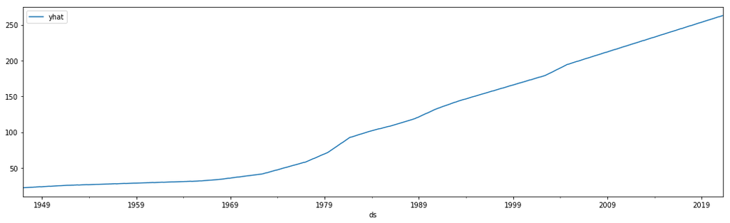

```python
forecast_future.plot(x='ds',y='yhat',figsize=(18,5))
```

### Forecasted time series graph

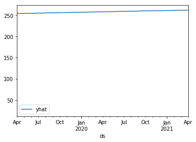

```python
forecast_future.plot(x='ds',y='yhat',xlim=('2019-04-01','2021-04-01'))
```